# Dissecting tumor transcriptional heterogeneity from multi-tumor single-cell RNA-seq data using GBCD

Yusha Liu

2024-05-08

## Overview

This vignette shows how to apply “generalized binary covariance decomposition” (GBCD) to jointly analyze single-cell RNA-seq (scRNA-seq) data from *malignant cells* collected from multiple patients and/or studies, using the gbcd package.

GBCD can effectively dissect tumor transcriptional heterogeneity into patient/study-specific and shared gene expression programs (GEPs). GBCD is “unsupervised” in that, unlike tumor-by-tumor (e.g., [Puram et al. (2017)](https://www.sciencedirect.com/science/article/pii/S0092867417312709)) and many harmonization approaches (e.g., [Harmony](https://portals.broadinstitute.org/harmony), [Liger](https://github.com/welch-lab/liger)), it does not use information about which cell comes from which tumor or study. Instead, GBCD only requires the combined scRNA-seq data from all tumors, which are stored as an $N \times J$ matrix $Y$ of expression values with entries $y_{ij}$, where $i=1,\dots,N$ indexes malignant cells and $j=1,\dots,J$ indexes genes. In typical applications, $Y$ contains log-transformed pseudo-count-modified UMI counts (“log-pc counts”).

GBCD ultimately yields a decomposition of the expression data matrix $Y$ into matrices $L$ and $F$ such that $Y \approx L F^T$, or equivalently,
$$y_{ij} \approx \sum_{k=1}^K l_{ik}
f_{jk}.$$
The $K$ components should be interpretable as GEPs, with $l_{ik}$ representing the membership of cell $i$ in GEP $k$, and $f_{jk}$ representing the effect of GEP $k$ on the expression of gene $j$. When $y_{ij}$ are log-pc counts, each $f_{jk}$ approximately represents the log-fold change (LFC) associated with membership in GEP $k$, so we refer to the $f_{jk}$ values as LFCs, and to the vector of LFCs $(f_{1k}, \dots, f_{Jk})^T$ as the “signature” of GEP $k$.

We begin our analysis by loading the needed R packages. Then we show how to apply GBCD to the HNSCC dataset and interpret the results.

```r
library(Seurat)
library(ggplot2)
library(cowplot)
library(RColorBrewer)
library(ggrepel)
library(pheatmap)
library(gridExtra)
devtools::load_all("/Users/yushaliu/Documents/git/gbcd")
```

## The HNSCC dataset

This dataset contained gene expression data for $n=2,176$ malignant cells collected from primary tumors from 10 HNSCC patients and matching lymph node (LN) metastases from 5 of these patients. [Puram et al. (2017)](https://www.sciencedirect.com/science/article/pii/S0092867417312709) found that each of these 10 patients clearly mapped to a molecular subtype of HNSCC, whose signatures were previously defined by analysis of bulk expression data of 279 [TCGA](https://www.ncbi.nlm.nih.gov/pmc/articles/PMC4311405/) HNSCC tumors.

Unlike more recently generated data sets, the HNSCC data were not UMI counts; rather, they were read counts produced by SMART-Seq2. Following [Puram et al. (2017)](https://www.sciencedirect.com/science/article/pii/S0092867417312709), we defined the transformed counts as $y_{ij} = \log_2(1 + \mathrm{TPM}_{ij}/10)$, where $\mathrm{TPM}_{ij}$ was the transcript-per-million (TPM) value for gene $j$ in cell $i$.

```r
load("/Users/yushaliu/Documents/git/gbcd/data/hnscc.RData")
dim(Y)
head(info)
# [1]  2176 17113
#                                             cell.id lymph.node cancer.cell
# HN26_P14_D11_S239_comb       HN26_P14_D11_S239_comb          1           1
# HN26_P25_H09_S189_comb       HN26_P25_H09_S189_comb          1           1
# HN26_P14_H06_S282_comb       HN26_P14_H06_S282_comb          1           1
# HN25_P25_C04_S316_comb       HN25_P25_C04_S316_comb          1           1
# HN26_P25_C09_S129_comb       HN26_P25_C09_S129_comb          1           1
# HNSCC26_P24_H05_S377_comb HNSCC26_P24_H05_S377_comb          1           1
#                           cell.type sample.id   subject  subtype
# HN26_P14_D11_S239_comb            0       T26 MEEI26_LN Atypical
# HN26_P25_H09_S189_comb            0       T26 MEEI26_LN Atypical
# HN26_P14_H06_S282_comb            0       T26 MEEI26_LN Atypical
# HN25_P25_C04_S316_comb            0       T25 MEEI25_LN    Basal
# HN26_P25_C09_S129_comb            0       T26 MEEI26_LN Atypical
# HNSCC26_P24_H05_S377_comb         0       T26 MEEI26_LN Atypical
```

## Visualize HNSCC data using *t*-SNE

```r
hnscc <- CreateSeuratObject(counts = t(Y), project = "HNSCC", meta.data = info)
# Warning: Feature names cannot have underscores ('_'), replacing with dashes
# ('-')
hnscc <- FindVariableFeatures(hnscc, selection.method = "vst", nfeatures = 5000)
all.genes <- rownames(hnscc)
hnscc <- ScaleData(hnscc, features = all.genes)
# Centering and scaling data matrix
hnscc <- RunPCA(hnscc, features = VariableFeatures(object = hnscc), npcs = 50, verbose = FALSE)
hnscc <- RunTSNE(hnscc, dims = 1:50)
```

We plot the 2-D *t*-SNE embedding of these $n=2,176$ malignant cells, which are colored by patient of origin and tumor stage (primary tumor, LN metastasis), and shaped by tumor molecular subtype. Due to the presence of strong inter-tumor heterogeneity, these cells demonstrate strong patient effects that are typical of cancer data; the major structure in the *t*-SNE visualization is the clustering of the cells by patient.

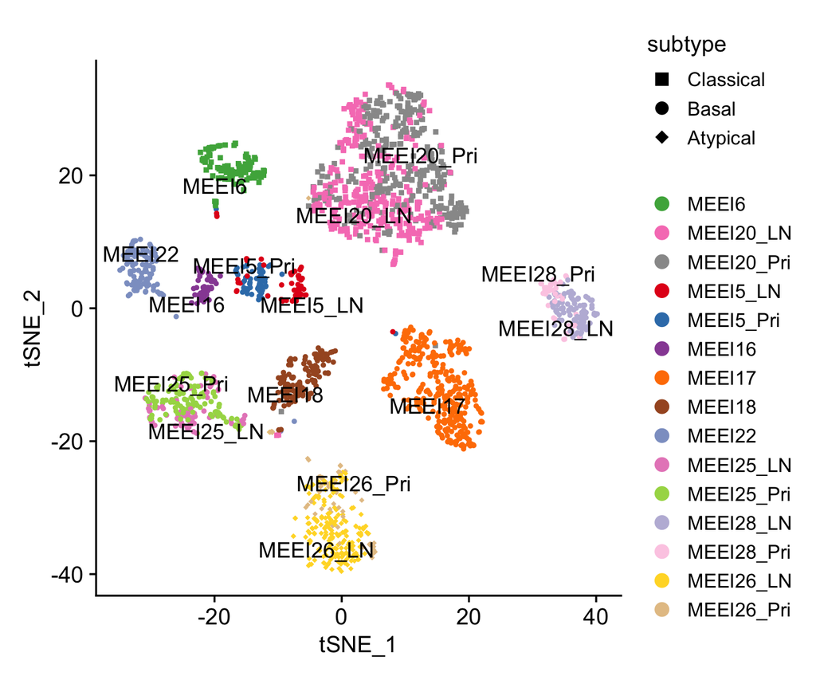

```r
DimPlot(hnscc, label = TRUE, repel = TRUE, pt.size = 1, reduction = "tsne", group.by = "subject", shape.by = "subtype", cols = subject_col) +
  guides(shape = guide_legend(override.aes = list(size = 3)), ncol = 1) + theme(text = element_text(size = 12)) +
  ggtitle("") + scale_shape_manual(values = c(15, 16, 18))
# Warning: Using `as.character()` on a quosure is deprecated as of rlang 0.3.0. Please use
# `as_label()` or `as_name()` instead.
# This warning is displayed once every 8 hours.
```

## Apply GBCD to estimate GEP memberships and signatures

To fit GBCD, users need to specify $Kmax$, an upper bound of the number of components $K$, just for initialization purposes; the final number of GEPs returned by GBCD is close to but often not equal to (and can be larger than) $Kmax$. Generally speaking, a larger $Kmax$ allows for identifying finer structure in tumor transcriptional heterogeneity, at the expense of higher computational cost. A good choice of $Kmax$ depends on the complexity of the analyzed data (e.g., the number of patients and studies contained), and is often unknown in advance. Based on our experience, a value of $Kmax$ between 10 and 40 usually works well, and users are encouraged to explore and compare the results for different values of $Kmax$.

Users also need to specify a prior for GEP membership values. GBCD assigns a “generalized binary” (GB) prior independently to each entry of $L$,
$$l_{ik}\sim (1-\pi_k^l) \delta_0 + \pi_k^l \:
N_{+} (\mu_k, \sigma_k^2),$$
where the ratio $\sigma_k/\mu_k$ is fixed at some pre-specified small value. In this application we set $\sigma_k/\mu_k = 0.04$ for each $k$. A smaller ratio is generally recommended for larger datasets containing more cells, and a value between 0.01 to 0.1 usually works well.

For time reason, in the following call, we set `Kmax = 12`, and set the number of backfit iterations respectively to `maxiter1 = 100` (for initializing $L$), `maxiter2 = 50` (for estimating $L$), and `maxiter3 = 100` (for estimating $F$). However, users are encouraged to explore larger values of `Kmax` and set `maxiter1`, `maxiter2`, `maxiter3` to their default values, which take longer to run.

```r
res.gbcd <- fit_gbcd(Y = Y, Kmax = 12, maxiter1 = 100, maxiter2 = 50, maxiter3 = 100,
                     prior = flash_ebnm(prior_family = "generalized_binary", scale = 0.04), verbose = 0)
# Warning in report.maxiter.reached(verbose.lvl): Maximum number of iterations
# reached.

# Warning in report.maxiter.reached(verbose.lvl): Maximum number of iterations
# reached.

# Warning in report.maxiter.reached(verbose.lvl): Maximum number of iterations
# reached.

# Warning in report.maxiter.reached(verbose.lvl): Maximum number of iterations
# reached.
# [1] "Form cell by cell covariance matrix..."
#    user  system elapsed
#  15.984   0.143  16.718
# [1] "Initialize GEP membership matrix L..."
# Adding factor 1 to flash object...
# Wrapping up...
# Done.
# Adding factor 2 to flash object...
# Adding factor 3 to flash object...
# Adding factor 4 to flash object...
# Adding factor 5 to flash object...
# Adding factor 6 to flash object...
# Adding factor 7 to flash object...
# Adding factor 8 to flash object...
# Adding factor 9 to flash object...
# Adding factor 10 to flash object...
# Adding factor 11 to flash object...
# Adding factor 12 to flash object...
# Wrapping up...
# Done.
#    user  system elapsed
#  43.227   3.273  46.795
# [1] "Estimate GEP membership matrix L..."
#    user  system elapsed
#  73.979   3.391  77.705
# [1] "Estimate GEP signature matrix F..."
# Backfitting 23 factors (tolerance: 5.55e-01)...
#   Difference between iterations is within 1.0e+03...
#   Difference between iterations is within 1.0e+02...
#   Difference between iterations is within 1.0e+01...
#   --Maximum number of iterations reached!
# Wrapping up...
# Done.
#    user  system elapsed
# 439.228  20.305 461.062
```

Note that users can also specify other nonnegative priors for GEP membership values, as long as they are defined in the [ebnm](https://stephenslab.github.io/ebnm/) package. For example, users can specify a point exponential prior by setting `prior = ebnm::ebnm_point_exponential` in the call to `fit_gbcd`. However, we find that the GB prior usually performs the best empirically to dissect tumor transcriptional heterogeneity from multiple samples and/or studies.

The above call takes about 10 minutes to run on a laptop.

## Interpret GBCD results from the HNSCC data

Take a look at a summary of the GBCD results.

```r
summary(res.gbcd)
#   Length Class  Mode
# L 45696  -none- numeric
# F     3  -none- list
```

## GEP membership estimates

We now look at the matrix of GEP membership estimates $L$ with entries $l_{ik}$ representing the membership of cell $i$ in GEP $k$. Here we show the top rows of $L$.

```r
head(round(res.gbcd$L, 3))
#                           Baseline GEP1  GEP2  GEP3  GEP4  GEP5  GEP6  GEP7
# HN26_P14_D11_S239_comb       0.735    0 0.000 0.895 0.354 0.000 0.000 0.573
# HN26_P25_H09_S189_comb       0.657    0 0.141 0.776 0.000 0.479 0.000 0.617
# HN26_P14_H06_S282_comb       0.791    0 0.244 0.710 0.606 0.000 0.000 0.713
# HN25_P25_C04_S316_comb       0.412    0 0.661 0.212 0.000 0.649 0.000 0.000
# HN26_P25_C09_S129_comb       0.645    0 0.000 0.743 0.000 0.382 0.000 0.733
# HNSCC26_P24_H05_S377_comb    0.586    0 0.000 0.739 0.000 0.405 0.345 0.696
#                           GEP8  GEP9 GEP10 GEP11 GEP12 GEP13 GEP14 GEP15 GEP16
# HN26_P14_D11_S239_comb       0 0.000 0.664     0     0 0.437 0.000 0.000 0.000
# HN26_P25_H09_S189_comb       0 0.000 0.000     0     0 0.471 0.000 0.591 0.000
# HN26_P14_H06_S282_comb       0 0.000 0.000     0     0 0.452 0.000 0.000 0.585
# HN25_P25_C04_S316_comb       0 0.695 0.672     0     0 0.606 0.793 0.670 0.000
# HN26_P25_C09_S129_comb       0 0.000 0.000     0     0 0.000 0.000 0.748 0.000
# HNSCC26_P24_H05_S377_comb    0 0.000 0.000     0     0 0.000 0.461 0.586 0.000
#                           GEP17 GEP18 GEP19 GEP20
# HN26_P14_D11_S239_comb        0  0.00     0     0
# HN26_P25_H09_S189_comb        0  0.00     0     0
# HN26_P14_H06_S282_comb        0  0.36     0     0
# HN25_P25_C04_S316_comb        0  0.00     0     0
# HN26_P25_C09_S129_comb        0  0.00     0     0
# HNSCC26_P24_H05_S377_comb     0  0.00     0     0
```

Create a heatmap to visualize GEP membership estimates.

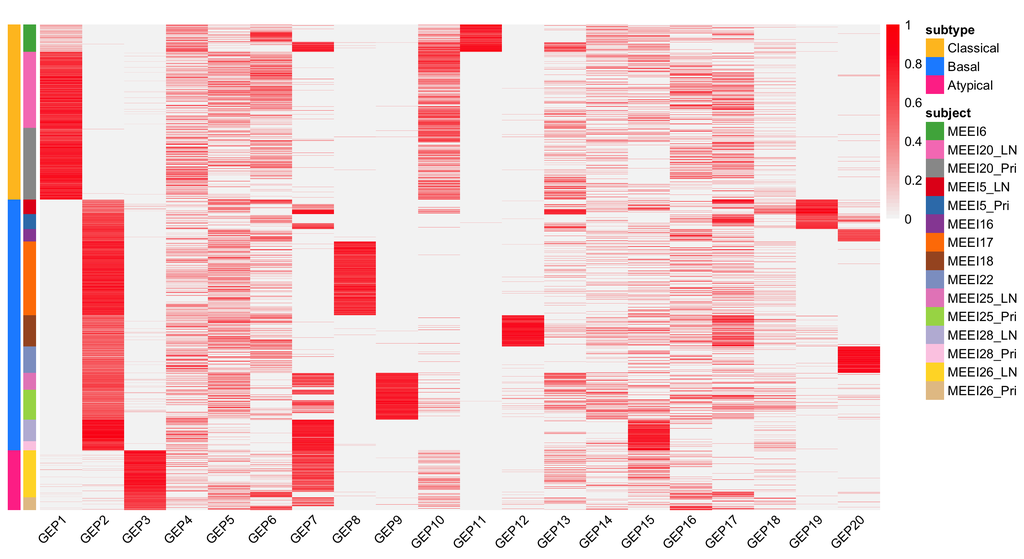

```r
### add the sample and molecular subtype annotation of cells to visualize the GEP memberships
anno <- data.frame(subject=info$subject, subtype=info$subtype)
rownames(anno) <- rownames(res.gbcd$L)
anno_colors <- list(subject=subject_col, subtype=subtype_col)
cols <- colorRampPalette(c("gray96", "red"))(50)
brks <- seq(0, 1, 0.02)

### plot the annotated heatmap of GEP memberships
pheatmap(res.gbcd$L[order(anno$subject), -c(1)], cluster_rows = FALSE, cluster_cols = FALSE, show_rownames = FALSE, annotation_row = anno, annotation_colors = anno_colors, annotation_names_row = FALSE, angle_col = 45, fontsize = 10, color = cols, breaks = brks, main = "")
```

This heatmap shows the membership values of the $n=2,176$ cells (rows) for 20 GEPs (columns; intercept excluded). Cells are arranged top-to-bottom by tumor molecular subtype and patient of origin. Membership values are rescaled separately for GEPs so that the maximum membership for each GEP is always 1.

From this heatmap, we see that GEPs 1-3 correspond closely to the molecular subtypes previously defined based on bulk RNA-seq data: GEP1 is largely active only in cells from the 2 classical patients, GEP2 is mainly active in cells from the 7 basal patients, and GEP3 is mainly active in cells from the 1 atypical patient. This demonstrates that GBCD can extract the molecular subtype information *de novo* from the single cell data alone.

Among other GEPs, some are active predominantly in an individual patient and can thus be interpreted as patient-specific GEPs, such as GEPs 8,9,11; other GEPs are shared across patients but do not correspond to molecular subtypes. The degree of patient-specific (vs. shared across patients) expression for each GEP can be quantified using the function `gep_annotation`.

## GEP signature estimates

We next look at the matrix of GEP signature estimates $F$ with each entry $f_{jk}$ approximately representing the $\text{log}_2$-fold change associated with membership in GEP $k$.

```r
head(round(res.gbcd$F$lfc, 3))
#              Baseline   GEP1   GEP2   GEP3   GEP4   GEP5   GEP6   GEP7   GEP8
# C9orf152        0.000  0.063  0.000  0.004  0.000  0.003  0.000  0.000  0.000
# ELMO2           2.057  0.000 -0.469  0.738  0.003 -0.271 -0.065  0.016 -0.050
# PNMA1           1.934  0.002 -1.329  0.034 -0.001  0.019 -0.043 -0.018 -0.018
# MMP2            0.759 -0.464  2.447 -0.912 -0.005  0.785 -0.597 -0.004 -1.207
# TMEM216         2.136  1.050 -0.650  0.021  0.006 -0.012 -0.115 -0.021 -0.002
# TRAF3IP2-AS1    0.216  0.293  0.000  0.588  0.001  0.132  0.000  0.003  0.000
#               GEP9  GEP10  GEP11  GEP12 GEP13  GEP14  GEP15  GEP16  GEP17
# C9orf152     0.000 -0.003 -0.004  0.000 0.003  0.084  0.000  0.001  0.000
# ELMO2        0.082  0.005 -0.765 -0.036 0.347 -0.354 -0.565 -0.019 -0.003
# PNMA1        2.155  0.065 -0.017  0.339 0.731  0.012 -0.047  0.014 -0.002
# MMP2         0.050 -0.031  0.026 -0.868 0.801  0.350 -0.509  0.035 -0.295
# TMEM216      1.138 -0.089 -0.396 -0.259 0.191 -0.605 -0.012 -0.428 -0.055
# TRAF3IP2-AS1 0.005  0.014  0.010 -0.004 0.026  0.449 -0.002  0.019 -0.001
#               GEP18  GEP19  GEP20
# C9orf152      0.014 -0.001  0.000
# ELMO2        -0.104  0.060  0.019
# PNMA1        -0.007 -0.007  0.022
# MMP2         -1.499 -0.020  3.791
# TMEM216      -0.037 -0.012  0.029
# TRAF3IP2-AS1 -0.002  0.042 -0.001
```

Create a volcano plot to visualize the gene signature for a given GEP (here we plot GEP2 as an example), which also makes use of measures of significance of LFCs produced by GBCD, including *z-score* and *local false sign rate*, or [*lfsr*](https://academic.oup.com/biostatistics/article/18/2/275/2557030).

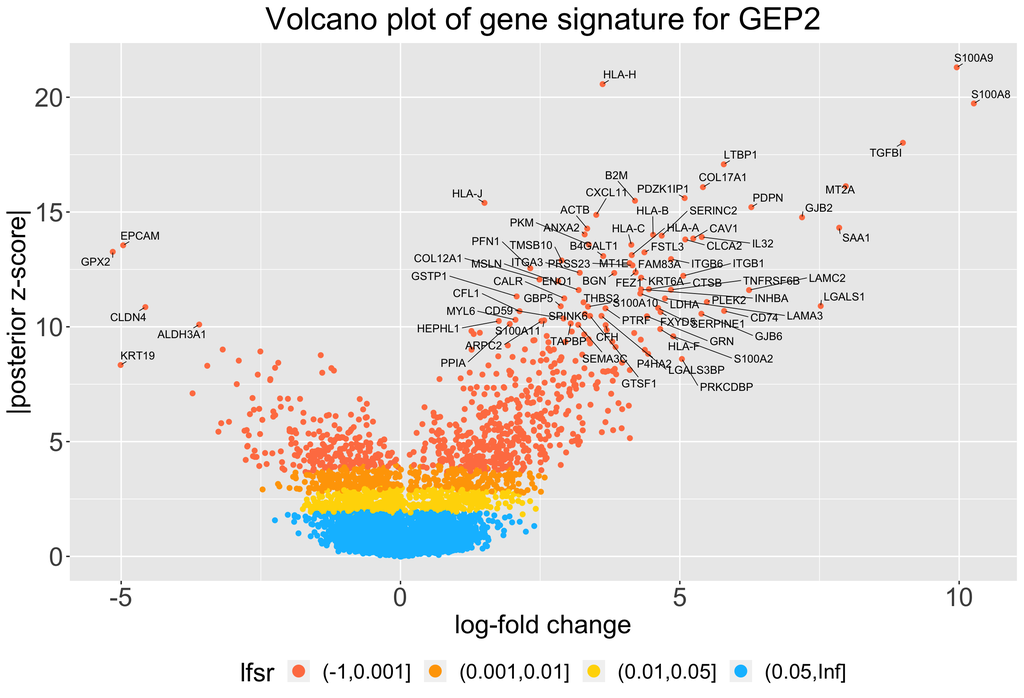

```r
pdat <- data.frame(gene = rownames(res.gbcd$F$lfc),
                   lfc = res.gbcd$F$lfc[, "GEP2"],
                   z = abs(res.gbcd$F$z_score[, "GEP2"]),
                   lfsr = res.gbcd$F$lfsr[, "GEP2"],
                   stringsAsFactors = FALSE)
pdat <- transform(pdat, lfsr = cut(lfsr, c(-1, 0.001, 0.01, 0.05, Inf)))
rows  <- with(pdat, which(!(abs(lfc) > quantile(abs(lfc), 0.998) | (z > 10))))
pdat[rows, "gene"] <- ""

ggplot(pdat, aes(x = lfc, y = z, color = lfsr, label = gene)) + geom_point() +
  geom_text_repel(color = "black", size = 3, segment.color = "black", segment.size = 0.25, min.segment.length = 0, max.overlaps = Inf, na.rm = TRUE) +
  scale_color_manual(values = c("coral", "orange", "gold", "deepskyblue")) +
  labs(x = "log-fold change", y = "|posterior z-score|") +
  guides(colour = guide_legend(override.aes = list(size = 4))) +
  theme(plot.title = element_text(hjust = 0.5, size = 24), axis.text = element_text(size = 20), axis.title = element_text(size = 20), legend.title = element_text(size = 20), legend.text = element_text(size = 16), legend.position = "bottom") + ggtitle("Volcano plot of gene signature for GEP2")
```

## Session info

This is the version of R and the packages that were used to generate these results.

```r
sessionInfo()
# R version 4.3.1 (2023-06-16)
# Platform: aarch64-apple-darwin20 (64-bit)
# Running under: macOS Sonoma 14.3
#
# Matrix products: default
# BLAS:   /Library/Frameworks/R.framework/Versions/4.3-arm64/Resources/lib/libRblas.0.dylib
# LAPACK: /Library/Frameworks/R.framework/Versions/4.3-arm64/Resources/lib/libRlapack.dylib;  LAPACK version 3.11.0
#
# locale:
# [1] en_US.UTF-8/en_US.UTF-8/en_US.UTF-8/C/en_US.UTF-8/en_US.UTF-8
#
# time zone: America/New_York
# tzcode source: internal
#
# attached base packages:
# [1] stats     graphics  grDevices utils     datasets  methods   base
#
# other attached packages:
# [1] gbcd_0.0.0.9000    gridExtra_2.3      pheatmap_1.0.12    ggrepel_0.9.3
# [5] RColorBrewer_1.1-3 cowplot_1.1.1      ggplot2_3.4.3      Seurat_3.1.4
#
# loaded via a namespace (and not attached):
#   [1] RcppAnnoy_0.0.21     splines_4.3.1        later_1.3.1
#   [4] tibble_3.2.1         lifecycle_1.0.3      Rdpack_2.6
#   [7] mixsqp_0.3-48        rprojroot_2.0.3      globals_0.16.2
#  [10] processx_3.8.2       lattice_0.21-8       MASS_7.3-60
#  [13] magrittr_2.0.3       plotly_4.10.2        sass_0.4.7
#  [16] rmarkdown_2.24       jquerylib_0.1.4      yaml_2.3.7
#  [19] remotes_2.4.2.1      plotrix_3.8-4        qqconf_1.3.2
#  [22] httpuv_1.6.11        sn_2.1.1             sctransform_0.3.5
#  [25] sessioninfo_1.2.2    pkgbuild_1.4.2       reticulate_1.32.0
#  [28] pbapply_1.7-2        multcomp_1.4-25      pkgload_1.3.2.1
#  [31] quadprog_1.5-8       Rtsne_0.16           purrr_1.0.2
#  [34] BiocGenerics_0.46.0  TH.data_1.1-2        sandwich_3.1-0
#  [37] fastTopics_0.6-142   irlba_2.3.5.1        listenv_0.9.0
#  [40] TFisher_0.2.0        MatrixModels_0.5-2   fitdistrplus_1.1-11
#  [43] parallelly_1.36.0    leiden_0.4.3         codetools_0.2-19
#  [46] tidyselect_1.2.0     farver_2.1.1         matrixStats_1.0.0
#  [49] stats4_4.3.1         mathjaxr_1.6-0       jsonlite_1.8.7
#  [52] multtest_2.56.0      ellipsis_0.3.2       ggridges_0.5.6
#  [55] survival_3.5-7       progress_1.2.2       tools_4.3.1
#  [58] ica_1.0-3            Rcpp_1.0.11          glue_1.6.2
#  [61] mnormt_2.1.1         xfun_0.40            metap_1.9
#  [64] usethis_2.2.2        dplyr_1.1.3          withr_2.5.0
#  [67] numDeriv_2016.8-1.1  fastmap_1.1.1        fansi_1.0.4
#  [70] SparseM_1.81         callr_3.7.3          digest_0.6.33
#  [73] rsvd_1.0.5           truncnorm_1.0-9      R6_2.5.1
#  [76] mime_0.12            colorspace_2.1-0     utf8_1.2.3
#  [79] tidyr_1.3.0          generics_0.1.3       data.table_1.14.8
#  [82] prettyunits_1.1.1    httr_1.4.7           htmlwidgets_1.6.2
#  [85] scatterplot3d_0.3-44 deconvolveR_1.2-1    uwot_0.1.16
#  [88] pkgconfig_2.0.3      gtable_0.3.4         tsne_0.1-3.1
#  [91] lmtest_0.9-40        htmltools_0.5.6      profvis_0.3.8
#  [94] MCMCpack_1.6-3       horseshoe_0.2.0      scales_1.2.1
#  [97] Biobase_2.60.0       png_0.1-8            ashr_2.2-63
# [100] knitr_1.44           rstudioapi_0.15.0    reshape2_1.4.4
# [103] coda_0.19-4          nlme_3.1-163         cachem_1.0.8
# [106] zoo_1.8-12           Polychrome_1.5.1     stringr_1.5.0
# [109] KernSmooth_2.23-22   parallel_4.3.1       miniUI_0.1.1.1
# [112] softImpute_1.4-1     desc_1.4.2           pillar_1.9.0
# [115] grid_4.3.1           vctrs_0.6.3          RANN_2.6.1
# [118] urlchecker_1.0.1     promises_1.2.1       xtable_1.8-4
# [121] cluster_2.1.4        evaluate_0.21        invgamma_1.1
# [124] mvtnorm_1.2-3        cli_3.6.1            compiler_4.3.1
# [127] rlang_1.1.1          crayon_1.5.2         SQUAREM_2021.1
# [130] future.apply_1.11.0  mutoss_0.1-13        labeling_0.4.3
# [133] ps_1.7.5             plyr_1.8.8           fs_1.6.3
# [136] stringi_1.7.12       viridisLite_0.4.2    munsell_0.5.0
# [139] flashier_1.0.53      lazyeval_0.2.2       devtools_2.4.5
# [142] quantreg_5.97        Matrix_1.6-1         hms_1.1.3
# [145] patchwork_1.1.3      future_1.33.0        mcmc_0.9-7
# [148] shiny_1.7.5          trust_0.1-8          rbibutils_2.2.16
# [151] ROCR_1.0-11          igraph_1.5.1         memoise_2.0.1
# [154] RcppParallel_5.1.7   bslib_0.5.1          ebnm_1.1-26
# [157] ape_5.7-1
```